# My First Markdown Document

Andrew McCracken

Febuary 1, 2022

Add text here. just use it like a typewriter and add as much or as little as you like

New text appears here in a separate paragraph

Use 2 or more blank spaces at the end of a single-spaced line to write without spaces between lines

Andrew McCracken  
Department of Biology  
Unversity of Vermont

# First-Level Header

## Second-Level Header

### Third-Level Header

Use edit R markdown format settings –> output options to change fonts, number section headings, and mess with other format options

# Basic Text Formatting

Italic *text*  
Bold **Text**  
Subscript <sub>text</sub>  
Superscript <sup>text</sup>  
Strike-through text

# Lists:

## Unordered Lists

- Iten 1
- Item 2
  - Item 2a
  - Item 2b

## Ordered List

1. Item 1
2. Item 2
3. Item 3
   - Item 3a
   - Item 3b

# Fencing:

In line fencing with a back-tick `to show anything in plain text with *no* formatting` which can be useful for many things

In line execution of r code inside the back-ticks by inserting r as the first element 6.1415927

3 back-ticks for a while section of plain text

```
everything in here is plaintext.
even single lines.

useful especially when showing other coding instructions
```

# Block Quotes with `>`

> to be or not to be, that is the question. wheather tis nobler.. blah blah blah

# Spacing line with 3 or more underscores

adds a line between the text…

# Links

http://example.com

[linked phrase](http://example.com)

# Images

[figure not shown]

alt text

At the bottom of the document:

# Tables

| First Header | Second Header |
| --- | --- |
| Content Cell | Content Cell |
| Content Cell | *Formatted Text* |

# LaTeX code for equations

We set off equations with `$` for brackets.

## In-Line vs Stand-Alone Equations

These equations such as $a = 3 + 4$ will appear inside a single line of text

These equations such as
$$a = 3 + 4$$
will appear in a line of their own

## Subscripts and Superscripts

using the `_` for subscripts, `^` for superscripts, and `{}` for multiple items
$$H_0 = Z_{a + b}$$

$$S = cA^z$$

Elements can be coupled and nested

$$S = cA^z_1 + z_{2+x}$$

## Fractions and Greek Symbols

use `\SymbolName` and type name of Greek symbol `\beta`
use `\frac{numerator}{denominator}` for fractions
$$\alpha = \frac{\beta}{\delta + \gamma_x}$$

## Summation Signs

$$z = \sum_{i=1}^x{K}$$

## Escape the backslash with a costom term

costom backslash term `\backslash`
$$\backslash \alpha \le b \backslash$$

## Rendering plaintext in a LaTeX equation

Without using plaintext rendering
$$P(Occurence of Species A) = Z$$

with using plaintext rendering `\mbox{text}`
$$P(\mbox{Occurence of Species A}) = Z$$

# Code chunks

```r
# dont forget to start with comments!
#preliminaries
library(ggplot2)
pred <- 1:10 #vector of 10 integers
res <- runif(10) # random uniform values

#print Random numbers
print(res)
```

```
##  [1] 0.071366133 0.001386432 0.155811920 0.009157531 0.040093201 0.355253506
##  [7] 0.877443872 0.829604425 0.529052634 0.741826260
```

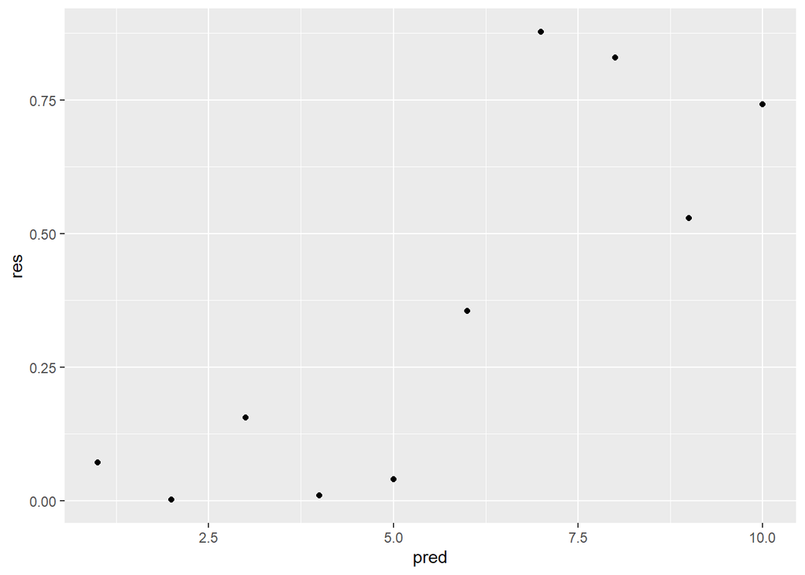

```r
#plot Graog
qplot(x=pred, y=res)
```

now back to writing text in our markdown document, including LaTeX eqiuations if we need them as $a+b$ inserted in the middle of my sentence

# Moving code from Markdown file to *.R file

This will take all R code from a markdown file and turn it into an R.script

```
library(knitr)
purl("name_of_markdown_file.rmd")
```